# An Introduction to Statistical Learning

#### **12.** This problem involves writing functions.

1. Write a function, Power(), that prints out the result of raising 2 to the 3rd power. In other words, your function should compute $2^3$ and print out the results.

```r
Power = function(){
x=2^3
print(x)
}
```

2. Create a new function, Power2(), that allows you to pass any two numbers, x and a, and prints out the value of $x^a$.

```r
Power2 = function(x, a){
y= x^a
print(y)
}
```

3. Using the Power2() function that you just wrote, compute $10^3$, $8^{17}$, and $131^3$.

```r
Power2(10,3)
```

```
## [1] 1000
```

```r
Power2(8, 17)
```

```
## [1] 2.2518e+15
```

```r
Power2(131, 3)
```

```
## [1] 2248091
```

4. Now create a new function, Power3(), that actually returns the result $x^a$ as an R object, rather than simply printing it to the screen.

```r
Power3 = function(x, a){
result= x^a
return(result)
}
```

5. Now using the Power3() function, create a plot of $f(x)=x^2$. The x-axis should display a range of integers from 1 to 10, and the y-axis should display $x^2$.

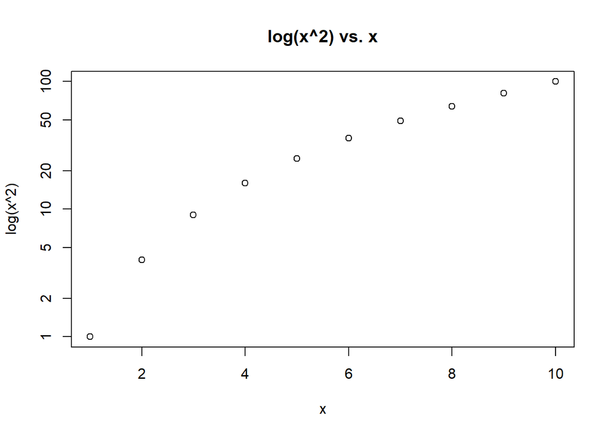

```r
x = 1:10
plot(x, Power3(x,2), log="y", main="log(x^2) vs. x",
     xlab="x", ylab="log(x^2)")
```

Create a function, PlotPower(), that allows you to create a plot of x against $x^a$ for a fixed a and for a range of values of x.

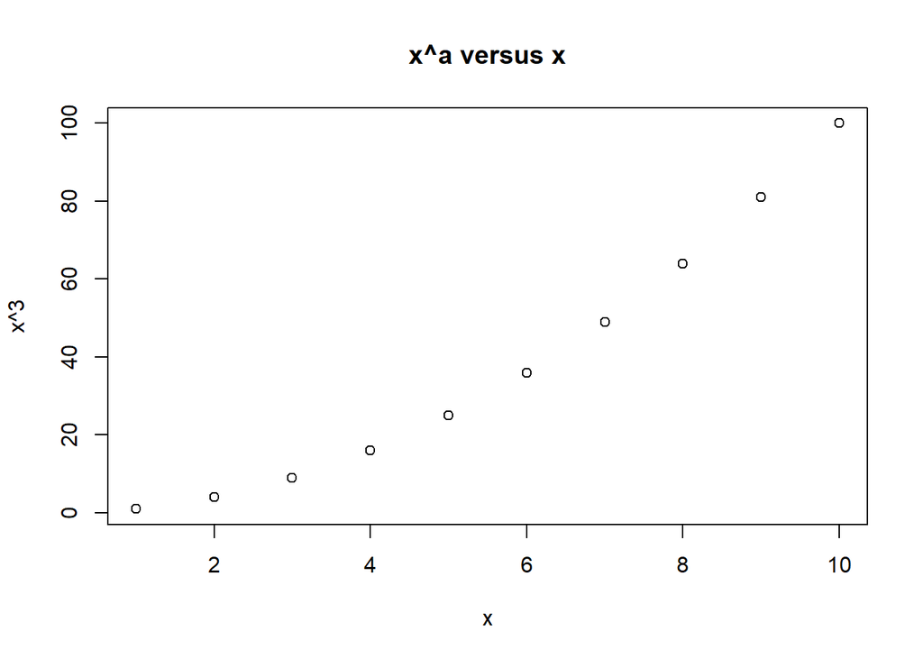

```r
PlotPower = function(x, a) {
  plot(x, Power3(x,2), main="x^a versus x",
       xlab="x", ylab=paste0("x^",a))
}
PlotPower(1:10,3)
```

#### **13.** Using the Boston data set, fit classification models in order to predict whether a given suburb has a crime rate above or below the median. Explore logistic regression, LDA, and KNN models using various subsets of the predictors. Describe your findings.

```r
data(Auto)
crim01 = ifelse(Boston$crim > median(Boston$crim), 1,0)
boston_df = data.frame(Boston, crim01)
summary(boston_df)
```

```
##       crim                zn             indus            chas
##  Min.   : 0.00632   Min.   :  0.00   Min.   : 0.46   Min.   :0.00000
##  1st Qu.: 0.08204   1st Qu.:  0.00   1st Qu.: 5.19   1st Qu.:0.00000
##  Median : 0.25651   Median :  0.00   Median : 9.69   Median :0.00000
##  Mean   : 3.61352   Mean   : 11.36   Mean   :11.14   Mean   :0.06917
##  3rd Qu.: 3.67708   3rd Qu.: 12.50   3rd Qu.:18.10   3rd Qu.:0.00000
##  Max.   :88.97620   Max.   :100.00   Max.   :27.74   Max.   :1.00000
##       nox               rm             age              dis
##  Min.   :0.3850   Min.   :3.561   Min.   :  2.90   Min.   : 1.130
##  1st Qu.:0.4490   1st Qu.:5.886   1st Qu.: 45.02   1st Qu.: 2.100
##  Median :0.5380   Median :6.208   Median : 77.50   Median : 3.207
##  Mean   :0.5547   Mean   :6.285   Mean   : 68.57   Mean   : 3.795
##  3rd Qu.:0.6240   3rd Qu.:6.623   3rd Qu.: 94.08   3rd Qu.: 5.188
##  Max.   :0.8710   Max.   :8.780   Max.   :100.00   Max.   :12.127
##       rad              tax           ptratio          black
##  Min.   : 1.000   Min.   :187.0   Min.   :12.60   Min.   :  0.32
##  1st Qu.: 4.000   1st Qu.:279.0   1st Qu.:17.40   1st Qu.:375.38
##  Median : 5.000   Median :330.0   Median :19.05   Median :391.44
##  Mean   : 9.549   Mean   :408.2   Mean   :18.46   Mean   :356.67
##  3rd Qu.:24.000   3rd Qu.:666.0   3rd Qu.:20.20   3rd Qu.:396.23
##  Max.   :24.000   Max.   :711.0   Max.   :22.00   Max.   :396.90
##      lstat            medv           crim01
##  Min.   : 1.73   Min.   : 5.00   Min.   :0.0
##  1st Qu.: 6.95   1st Qu.:17.02   1st Qu.:0.0
##  Median :11.36   Median :21.20   Median :0.5
##  Mean   :12.65   Mean   :22.53   Mean   :0.5
##  3rd Qu.:16.95   3rd Qu.:25.00   3rd Qu.:1.0
##  Max.   :37.97   Max.   :50.00   Max.   :1.0
```

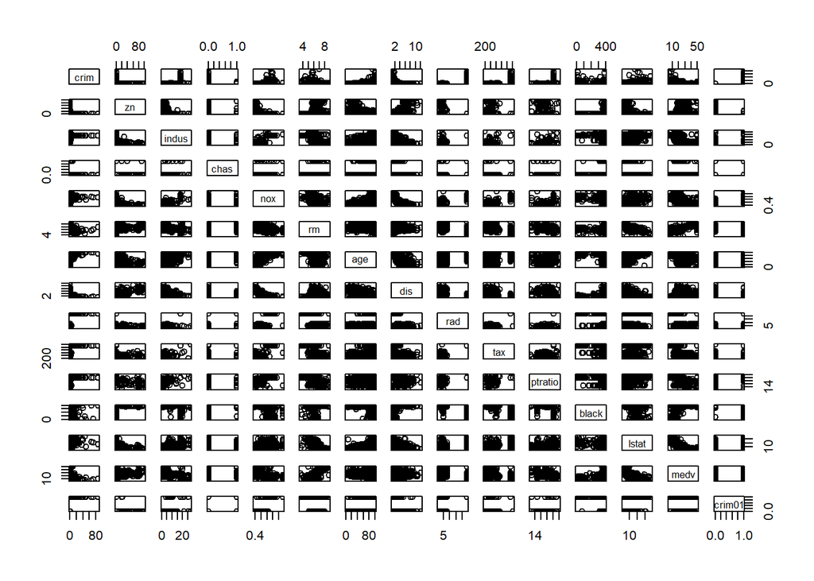

```r
pairs(boston_df)
```

```r
cor(boston_df)
```

```
##                crim          zn       indus         chas         nox
## crim     1.00000000 -0.20046922  0.40658341 -0.055891582  0.42097171
## zn      -0.20046922  1.00000000 -0.53382819 -0.042696719 -0.51660371
## indus    0.40658341 -0.53382819  1.00000000  0.062938027  0.76365145
## chas    -0.05589158 -0.04269672  0.06293803  1.000000000  0.09120281
## nox      0.42097171 -0.51660371  0.76365145  0.091202807  1.00000000
## rm      -0.21924670  0.31199059 -0.39167585  0.091251225 -0.30218819
## age      0.35273425 -0.56953734  0.64477851  0.086517774  0.73147010
## dis     -0.37967009  0.66440822 -0.70802699 -0.099175780 -0.76923011
## rad      0.62550515 -0.31194783  0.59512927 -0.007368241  0.61144056
## tax      0.58276431 -0.31456332  0.72076018 -0.035586518  0.66802320
## ptratio  0.28994558 -0.39167855  0.38324756 -0.121515174  0.18893268
## black   -0.38506394  0.17552032 -0.35697654  0.048788485 -0.38005064
## lstat    0.45562148 -0.41299457  0.60379972 -0.053929298  0.59087892
## medv    -0.38830461  0.36044534 -0.48372516  0.175260177 -0.42732077
## crim01   0.40939545 -0.43615103  0.60326017  0.070096774  0.72323480
##                  rm         age         dis          rad         tax    ptratio
## crim    -0.21924670  0.35273425 -0.37967009  0.625505145  0.58276431  0.2899456
## zn       0.31199059 -0.56953734  0.66440822 -0.311947826 -0.31456332 -0.3916785
## indus   -0.39167585  0.64477851 -0.70802699  0.595129275  0.72076018  0.3832476
## chas     0.09125123  0.08651777 -0.09917578 -0.007368241 -0.03558652 -0.1215152
## nox     -0.30218819  0.73147010 -0.76923011  0.611440563  0.66802320  0.1889327
## rm       1.00000000 -0.24026493  0.20524621 -0.209846668 -0.29204783 -0.3555015
## age     -0.24026493  1.00000000 -0.74788054  0.456022452  0.50645559  0.2615150
## dis      0.20524621 -0.74788054  1.00000000 -0.494587930 -0.53443158 -0.2324705
## rad     -0.20984667  0.45602245 -0.49458793  1.000000000  0.91022819  0.4647412
## tax     -0.29204783  0.50645559 -0.53443158  0.910228189  1.00000000  0.4608530
## ptratio -0.35550149  0.26151501 -0.23247054  0.464741179  0.46085304  1.0000000
## black    0.12806864 -0.27353398  0.29151167 -0.444412816 -0.44180801 -0.1773833
## lstat   -0.61380827  0.60233853 -0.49699583  0.488676335  0.54399341  0.3740443
## medv     0.69535995 -0.37695457  0.24992873 -0.381626231 -0.46853593 -0.5077867
## crim01  -0.15637178  0.61393992 -0.61634164  0.619786249  0.60874128  0.2535684
##               black      lstat       medv      crim01
## crim    -0.38506394  0.4556215 -0.3883046  0.40939545
## zn       0.17552032 -0.4129946  0.3604453 -0.43615103
## indus   -0.35697654  0.6037997 -0.4837252  0.60326017
## chas     0.04878848 -0.0539293  0.1752602  0.07009677
## nox     -0.38005064  0.5908789 -0.4273208  0.72323480
## rm       0.12806864 -0.6138083  0.6953599 -0.15637178
## age     -0.27353398  0.6023385 -0.3769546  0.61393992
## dis      0.29151167 -0.4969958  0.2499287 -0.61634164
## rad     -0.44441282  0.4886763 -0.3816262  0.61978625
## tax     -0.44180801  0.5439934 -0.4685359  0.60874128
## ptratio -0.17738330  0.3740443 -0.5077867  0.25356836
## black    1.00000000 -0.3660869  0.3334608 -0.35121093
## lstat   -0.36608690  1.0000000 -0.7376627  0.45326273
## medv     0.33346082 -0.7376627  1.0000000 -0.26301673
## crim01  -0.35121093  0.4532627 -0.2630167  1.00000000
```

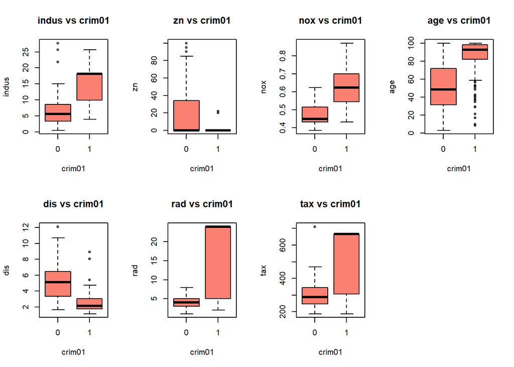

```r
par(mfrow=c(2, 4))
boxplot(indus ~ crim01, data = boston_df, main = "indus vs crim01", col="salmon")
boxplot(zn ~ crim01, data = boston_df, main = "zn vs crim01", col="salmon")
boxplot(nox ~ crim01, data = boston_df, main = "nox vs crim01", col="salmon")
boxplot(age ~ crim01, data = boston_df, main = "age vs crim01", col="salmon")
boxplot(dis ~ crim01, data = boston_df, main = "dis vs crim01", col="salmon")
boxplot(rad ~ crim01, data = boston_df, main = "rad vs crim01", col="salmon")
boxplot(tax ~ crim01, data = boston_df, main = "tax vs crim01", col="salmon")
```

```r
trainid = sample(1:nrow(boston_df), nrow(boston_df)*0.7, replace=F)
train = boston_df[trainid,]
test = boston_df[-trainid,]
train.X1 = cbind(train$zn, train$indus, train$chas, train$nox, train$rm, train$age, train$dis, train$rad, train$tax, train$ptratio, train$black, train$lstat, train$medv)
test.X1 = cbind(test$zn, test$indus, test$chas, test$nox, test$rm, test$age, test$dis, test$rad, test$tax, test$ptratio, test$black, test$lstat, test$medv)
train.X2 = cbind(train$age, train$tax, train$rad)
test.X2 = cbind(test$age, test$tax, test$rad)
```

LDA Models

```r
lda.fit = lda(crim01~age+tax+rad, data=train)
lda.fit.pred = predict(lda.fit, test)$class
table(lda.fit.pred, test$crim01)
```

```
##
## lda.fit.pred  0  1
##            0 64 18
##            1  6 64
```

```r
mean(lda.fit.pred != test$crim01)
```

```
## [1] 0.1578947
```

```r
lda.fit = lda(crim01~ . - crim -crim01, data=train)
lda.fit.pred = predict(lda.fit, test)$class
table(lda.fit.pred, test$crim01)
```

```
##
## lda.fit.pred  0  1
##            0 64 21
##            1  6 61
```

```r
mean(lda.fit.pred != test$crim01)
```

```
## [1] 0.1776316
```

QDA Models

```r
qda.fit = qda(crim01~age+tax+rad, data=train)
qda.fit.pred = predict(qda.fit, test)$class
table(qda.fit.pred, test$crim01)
```

```
##
## qda.fit.pred  0  1
##            0 66 37
##            1  4 45
```

```r
mean(qda.fit.pred != test$crim01)
```

```
## [1] 0.2697368
```

```r
qda.fit = qda(crim01~ . - crim -crim01, data=train)
qda.fit.pred = predict(qda.fit, test)$class
table(qda.fit.pred, test$crim01)
```

```
##
## qda.fit.pred  0  1
##            0 68 13
##            1  2 69
```

```r
mean(qda.fit.pred != test$crim01)
```

```
## [1] 0.09868421
```

Logistic Regression Models

```r
# Logistic Regression models
logit.fit = glm(crim01~age+tax+rad, data=train, family=binomial)
logit.fit.prob = predict(logit.fit, test, type="response")
logit.fit.pred = ifelse(logit.fit.prob > 0.5, 1, 0)
mean(logit.fit.pred != test$crim01)  # error rate
```

```
## [1] 0.1710526
```

```r
logit.fit = glm(crim01~. - crim -crim01, data=train, family=binomial)
logit.fit.prob = predict(logit.fit, test, type="response")
logit.fit.pred = ifelse(logit.fit.prob > 0.5, 1, 0)
mean(logit.fit.pred != test$crim01)  # error rate
```

```
## [1] 0.09210526
```

```r
set.seed(1)
require(class)
knn1.pred = knn(train.X1, test.X1, train$crim01, k=1)
mean(knn1.pred != test$crim01)
```

```
## [1] 0.08552632
```

```r
knn1.pred = knn(train.X1, test.X1, train$crim01, k=5)
mean(knn1.pred != test$crim01)
```

```
## [1] 0.09868421
```

```r
knn1.pred = knn(train.X1, test.X1, train$crim01, k=10)
mean(knn1.pred != test$crim01)
```

```
## [1] 0.1118421
```

```r
knn1.pred = knn(train.X1, test.X1, train$crim01, k=20)
mean(knn1.pred != test$crim01)
```

```
## [1] 0.1513158
```

```r
knn1.pred = knn(train.X1, test.X1, train$crim01, k=50)
mean(knn1.pred != test$crim01)
```

```
## [1] 0.1381579
```

```r
knn1.pred = knn(train.X1, test.X1, train$crim01, k=100)
mean(knn1.pred != test$crim01)
```

```
## [1] 0.2171053
```

```r
knn1.pred = knn(train.X1, test.X1, train$crim01, k=200)
mean(knn1.pred != test$crim01)
```

```
## [1] 0.2763158
```

```r
knn2.pred = knn(train.X2, test.X2, train$crim01, k=1)
mean(knn2.pred != test$crim01)
```

```
## [1] 0.09210526
```

```r
knn2.pred = knn(train.X2, test.X2, train$crim01, k=5)
mean(knn2.pred != test$crim01)
```

```
## [1] 0.06578947
```

```r
knn2.pred = knn(train.X2, test.X2, train$crim01, k=10)
mean(knn2.pred != test$crim01)
```

```
## [1] 0.1118421
```

```r
knn2.pred = knn(train.X2, test.X2, train$crim01, k=20)
mean(knn2.pred != test$crim01)
```

```
## [1] 0.1578947
```

```r
knn2.pred = knn(train.X2, test.X2, train$crim01, k=50)
mean(knn2.pred != test$crim01)
```

```
## [1] 0.1513158
```

```r
knn2.pred = knn(train.X2, test.X2, train$crim01, k=100)
mean(knn2.pred != test$crim01)
```

```
## [1] 0.2894737
```

```r
knn2.pred = knn(train.X2, test.X2, train$crim01, k=200)
mean(knn2.pred != test$crim01)
```

```
## [1] 0.2763158
```